# Exploratory Data Analysis for Relationship Between Words in NLP

Expedito Pinto de Paula Junior

11/26/2020

## Synopsis

The first step in building a predictive model for text is understanding the distribution and relationship between the words, tokens, and phrases in the text. The objective of this document is show some basiv relationships observed in the dataset and prepare to build a sample linguistic model in NLP (Natural Language Processing).

This document will address the following aspects:

1. Perform a thorough exploratory analysis of the data, understanding the **distribution of the words** and **relationship between the words** in the corpora.
2. Build figures and tables to **understand variation in the frequecies of words and word pairs** in the data.

```r
library(knitr)
library(kableExtra)
library(ggplot2)
library(tm)
library(cluster)
library(RWeka)
```

## Dataset

The dataset come from corpus called HC Corpora. In [Readme](http://www.corpora.heliohost.org/aboutcorpus.html) for details on the corpora available.This is the training data to get the basis to preparation of NLP.

```r
url <- "https://d396qusza40orc.cloudfront.net/dsscapstone/dataset/Coursera-SwiftKey.zip"

if(!file.exists("./data/Coursera-SwiftKey.zip")){
     download.file(url, destfile = "./data/Coursera-SwiftKey.zip")
}

unzip(zipfile = "./data/Coursera-SwiftKey.zip", exdir = "./data")
```

## Summary

The focus of this analyse are in English text files, this section will filter down to those that contains **“en_”** prefix for the training data that will be used. Bellow is the output of the preliminary analysis where are calculated size of the files, number of lines, the longest lines in each file and the number of the words in each file:

```r
flist <- list.files(path="./data", recursive=T, pattern=".*en_.*.txt")
l <- lapply(paste("./data", flist, sep="/"), function(f) {
   fsize <- file.info(f)[1]/1024/1024
   con <- file(f, open="r")
   lines <- readLines(con)
   nchars <- lapply(lines, nchar)
   maxchars <- which.max(nchars)
   nwords <- sum(sapply(strsplit(lines, "\\s+"), length))
   close(con)
   return(c(f, format(round(fsize, 2), nsmall=2), length(lines), maxchars, nwords))
})

df <- data.frame(matrix(unlist(l), nrow=length(l), byrow=T))
colnames(df) <- c("file", "size(MB)", "num.lines", "longest.line", "num.words")

kable(df) %>%
     add_header_above(c("Table 1: Summary training dataset (EN)" = 5)) %>%
     kable_styling(full_width = F) %>%
     column_spec(1, bold=T, border_right = T)
```

| Table 1: Summary training dataset (EN) file | Table 1: Summary training dataset (EN) size(MB) | Table 1: Summary training dataset (EN) num.lines | Table 1: Summary training dataset (EN) longest.line | Table 1: Summary training dataset (EN) num.words |
| --- | --- | --- | --- | --- |
| ./data/final/en_US/en_US.blogs.txt | 200.42 | 899288 | 483415 | 37334149 |
| ./data/final/en_US/en_US.news.txt | 196.28 | 1010242 | 123628 | 34372814 |
| ./data/final/en_US/en_US.twitter.txt | 159.36 | 2360148 | 26 | 30373565 |

## Pre-processing

```r
# Load files and reduce sample.
set.seed(123)

# Load Blog file
d_blog <- file("./data/final/en_US/en_US.blogs.txt", open = "r")
d_blog_lines <- readLines(d_blog)
n_blog_lines <- length(d_blog_lines)
blog_sample <- d_blog_lines[sample(1:n_blog_lines, n_blog_lines * 0.1, replace = FALSE)]
close(d_blog)
# Load News file
d_news <- file("./data/final/en_US/en_US.news.txt", open = "r")
d_news_lines <- readLines(d_news)
n_news_lines <- length(d_news_lines)
news_sample <- d_news_lines[sample(1:n_news_lines, n_news_lines * 0.2, replace = FALSE)]
close(d_news)
# Load Twitter file
d_twitter <- file("./data/final/en_US/en_US.twitter.txt", open = "r")
d_twitter_lines <- readLines(d_twitter)
n_twitter_lines <- length(d_news_lines)
twitter_sample <- d_twitter_lines[sample(1:n_twitter_lines, n_twitter_lines * 0.2, replace = FALSE)]
close(d_twitter)

blogCorpus <- VCorpus(VectorSource(list(blog_sample)))
newsCorpus <- VCorpus(VectorSource(list(news_sample)))
twitterCorpus <- VCorpus(VectorSource(list(twitter_sample)))
```

## Words Distribution

This section shows **words distribution** and the frequency of occurrance for each file analysed.Plots will show the most 30 frequency words.

### News

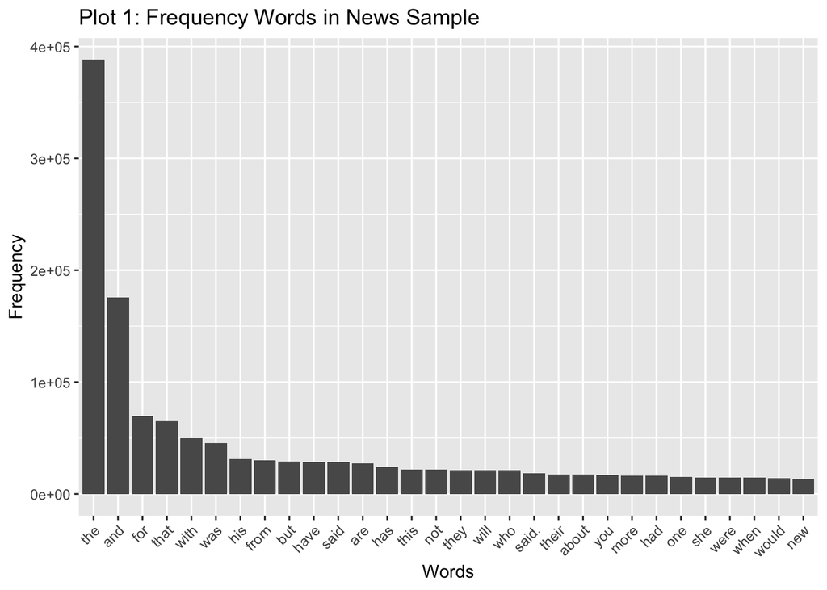

```r
dtm_news <- DocumentTermMatrix(newsCorpus)
newsWordFreq <- colSums(as.matrix(dtm_news))
ordNewsWordFreq <- order(newsWordFreq, decreasing = TRUE)

NewsDF <- newsWordFreq[head(ordNewsWordFreq, 30)]
NewsDF <- as.data.frame(NewsDF)
NewsDF <- data.frame(words=rownames(NewsDF), freq=NewsDF)
colnames(NewsDF) <- c("words", "freq")

ggplot(NewsDF, aes(x = reorder(words, -freq), y = freq))+
   geom_bar(stat = "identity")+
   theme(axis.text.x = element_text(angle=45, hjust=1)) +
   labs(x="Words") +
   labs(y="Frequency") +
   labs(title="Plot 1: Frequency Words in News Sample")
```

### Blog

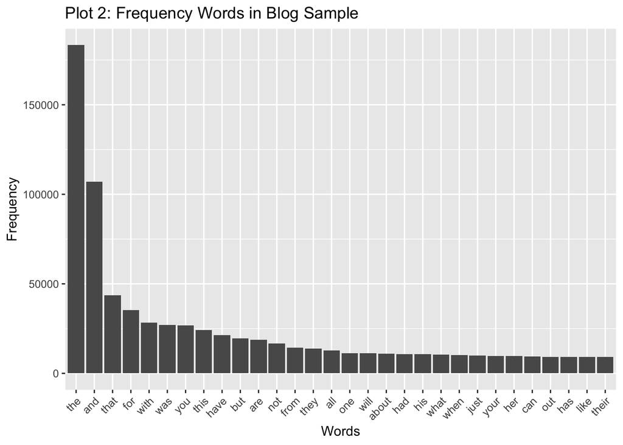

```r
dtm_blog <- DocumentTermMatrix(blogCorpus)
blogWordFreq <- colSums(as.matrix(dtm_blog))
ordBlogWordFreq <- order(blogWordFreq, decreasing = TRUE)

BlogDF <- blogWordFreq[head(ordBlogWordFreq, 30)]
BlogDF <- as.data.frame(BlogDF)
BlogDF <- data.frame(words=rownames(BlogDF), freq=BlogDF)
colnames(BlogDF) <- c("words", "freq")

ggplot(BlogDF, aes(x = reorder(words, -freq), y = freq))+
   geom_bar(stat = "identity")+
   theme(axis.text.x = element_text(angle=45, hjust=1))+
   labs(x="Words") +
   labs(y="Frequency") +
   labs(title="Plot 2: Frequency Words in Blog Sample")
```

### Twitter

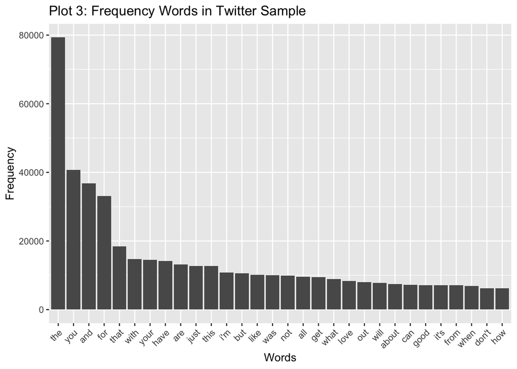

```r
dtm_twitter <- DocumentTermMatrix(twitterCorpus)
twitterWordFreq <- colSums(as.matrix(dtm_twitter))
ordTwitterWordFreq <- order(twitterWordFreq, decreasing = TRUE)

TwitterDF <- twitterWordFreq[head(ordTwitterWordFreq, 30)]
TwitterDF <- as.data.frame(TwitterDF)
TwitterDF <- data.frame(words=rownames(TwitterDF), freq=TwitterDF)
colnames(TwitterDF) <- c("words", "freq")

ggplot(TwitterDF, aes(x = reorder(words, -freq), y = freq))+
   geom_bar(stat = "identity")+
   theme(axis.text.x = element_text(angle=45, hjust=1))+
   labs(x="Words") +
   labs(y="Frequency") +
   labs(title="Plot 3: Frequency Words in Twitter Sample")
```

## Relationship between the words

To build the first simple model for relationship between the word will be build a basic [n-gram model](http://en.wikipedia.org/wiki/N-gram) for predicting the text word based. For each file will be used this method to see some relations between words.

### News

```r
TrigramTokenizer <- function(x) NGramTokenizer(x, Weka_control(min = 3, max = 3))

termdocmatrix <- TermDocumentMatrix(newsCorpus, control = list(tokenize = TrigramTokenizer))
tdfNews <- data.frame(inspect(termdocmatrix))
```

```
## <<TermDocumentMatrix (terms: 4658999, documents: 1)>>
## Non-/sparse entries: 4658999/0
## Sparsity           : 0%
## Maximal term length: 97
## Weighting          : term frequency (tf)
## Sample             :
##                   Docs
## Terms                 1
##   a lot of         2253
##   according to the 1116
##   as well as       1240
##   i don t          1588
##   it s a           1649
##   one of the       2932
##   out of the       1102
##   part of the      1141
##   the end of       1128
##   the u s          2167
```

```r
names(tdfNews) <- c("blog_data")
tdfNews$Freq <- rowSums(tdfNews)
tdfNews <- tdfNews[order(-tdfNews$Freq),]

kable(tdfNews) %>%
     add_header_above(c("Table 2: Relations Between words in News file (EN)" = 3)) %>%
     kable_styling(full_width = F) %>%
     column_spec(1, bold=T, border_right = T)
```

| Table 2: Relations Between words in News file (EN) | Table 2: Relations Between words in News file (EN) blog_data | Table 2: Relations Between words in News file (EN) Freq |
| --- | --- | --- |
| one of the | 2932 | 2932 |
| a lot of | 2253 | 2253 |
| the u s | 2167 | 2167 |
| it s a | 1649 | 1649 |
| i don t | 1588 | 1588 |
| as well as | 1240 | 1240 |
| part of the | 1141 | 1141 |
| the end of | 1128 | 1128 |
| according to the | 1116 | 1116 |
| out of the | 1102 | 1102 |

### Blog

```r
termdocmatrix <- TermDocumentMatrix(blogCorpus, control = list(tokenize = TrigramTokenizer))
tdfBlog <- data.frame(inspect(termdocmatrix))
```

```
## <<TermDocumentMatrix (terms: 2608419, documents: 1)>>
## Non-/sparse entries: 2608419/0
## Sparsity           : 0%
## Maximal term length: 110
## Weighting          : term frequency (tf)
## Sample             :
##              Docs
## Terms            1
##   a lot of    1133
##   as well as   681
##   be able to   629
##   i don t     1095
##   i want to    633
##   it was a     688
##   one of the  1460
##   some of the  655
##   the end of   660
##   to be a      704
```

```r
names(tdfBlog) <- c("blog_data")
tdfBlog$Freq <- rowSums(tdfBlog)
tdfBlog <- tdfBlog[order(-tdfBlog$Freq),]

kable(tdfBlog) %>%
     add_header_above(c("Table 3: Relations Between words in Blog file (EN)" = 3)) %>%
     kable_styling(full_width = F) %>%
     column_spec(1, bold=T, border_right = T)
```

| Table 3: Relations Between words in Blog file (EN) | Table 3: Relations Between words in Blog file (EN) blog_data | Table 3: Relations Between words in Blog file (EN) Freq |
| --- | --- | --- |
| one of the | 1460 | 1460 |
| a lot of | 1133 | 1133 |
| i don t | 1095 | 1095 |
| to be a | 704 | 704 |
| it was a | 688 | 688 |
| as well as | 681 | 681 |
| the end of | 660 | 660 |
| some of the | 655 | 655 |
| i want to | 633 | 633 |
| be able to | 629 | 629 |

### Twitter

```r
termdocmatrix <- TermDocumentMatrix(twitterCorpus, control = list(tokenize = TrigramTokenizer))
tdfTwitter <- data.frame(inspect(termdocmatrix))
```

```
## <<TermDocumentMatrix (terms: 1629794, documents: 1)>>
## Non-/sparse entries: 1629794/0
## Sparsity           : 0%
## Maximal term length: 117
## Weighting          : term frequency (tf)
## Sample             :
##                     Docs
## Terms                   1
##   can t wait         1176
##   for the follow      672
##   i can t            1204
##   i don t            2068
##   i love you          709
##   i m not             828
##   it s a              699
##   looking forward to  782
##   thank you for       787
##   thanks for the     2049
```

```r
names(tdfTwitter) <- c("blog_data")
tdfTwitter$Freq <- rowSums(tdfTwitter)
tdfTwitter <- tdfTwitter[order(-tdfTwitter$Freq),]

kable(tdfTwitter) %>%
     add_header_above(c("Table 3: Relations Between words in Blog file (EN)" = 3)) %>%
     kable_styling(full_width = F) %>%
     column_spec(1, bold=T, border_right = T)
```

[output not shown]

## Next Steps: Building Predictive Model.

For the predictive model, using text mining package to build a model based on the frequency of 1-gram to 3-gram phrases. The application will allow use to enter text. As the input is being provided word by word, it will be evaluated against our predictive model which will determine what word or a set of words are the most likely be the next token the user will input based on the frequency of n-grams.

The following are considerations for our model:

1. Our training data (based on blogs, news, and twitter data) has to be cleaned up as articles should not be included in our n-gram maps.
2. Remove apostrophes, and replace commas with spaces.
3. Use sample data for faster performance.
4. Remove profane words to avoid offensive content.
5. Combine the data and use the sample in the model.